# PracaDom6_MBogdańska

Magdalena Bogdańska

Modele liniowe i mieszane

## Task

Create following scenarios:

Generate continuous variable X_1 from distribution U[0,1]. Generate categorical variable X_2 with 2 levels with equal frequency. Generate Y in a way that it depends on interaction of X_1 and X_2.

Add random noise from N(0,1), all ANCOVA assumptions are met. Choose other distribution for epsilons, find a distribution with the same scale as N(0,1) for which you will get drop in power. Choose other distribution for epsilons in a way that the test for residual will not keep I type error rate.

For all these scenarios, produce plot that will compare power as a function of sample size. Moreover on this plot is should be visible that power for scenario 2 is lower than for scenario 1. And that I type error rate is different for scenario 3 and scenario 1.

## Example for first scenario.

```r
set.seed(77)
n<-100

X_1<-runif(n)
X_2<-rep(c("lev1","lev2"), length.out=n)
eps<-rnorm(n)
Y<- eps+ ifelse(X_2=="lev1" & X_1<0.3, 1.5, 0.5) + ifelse(X_2=="lev2"& X_1>0.5,1,0)
data<-data.frame(Y,X1=X_1,X2=factor(X_2))
```

One can see relations in data based on the folllowing plots:

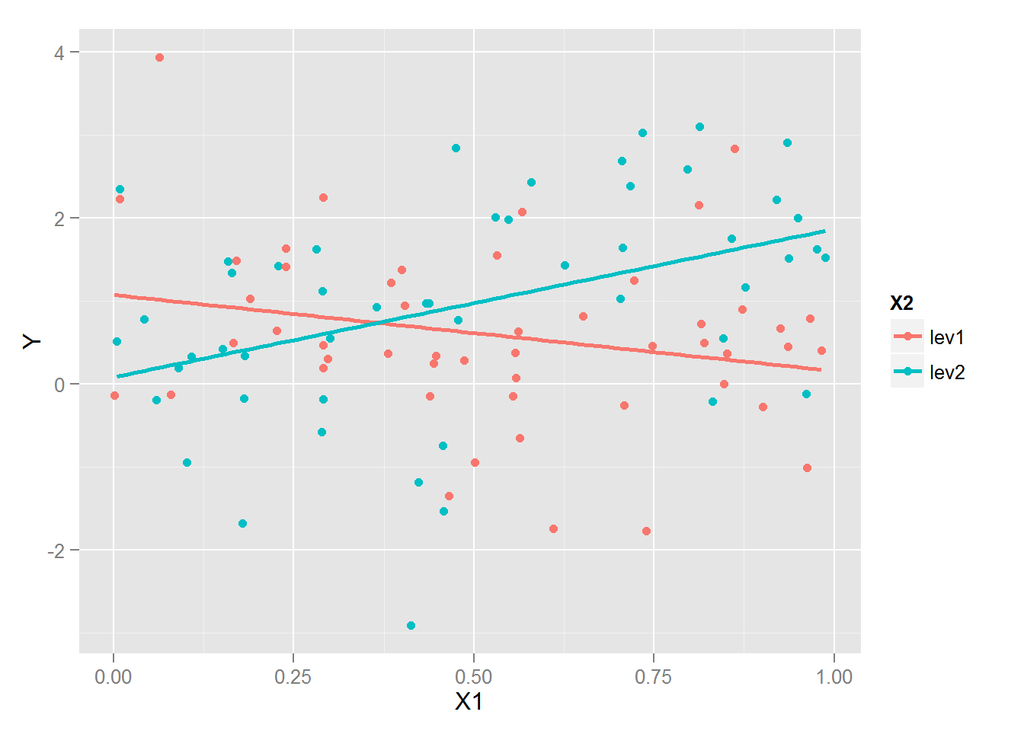

```r
library(ggplot2)
ggplot(data, aes(x=X1, y=Y, colour=X2)) + geom_smooth(method="lm", formula=y~x, se=FALSE, size=1) + geom_point()
```

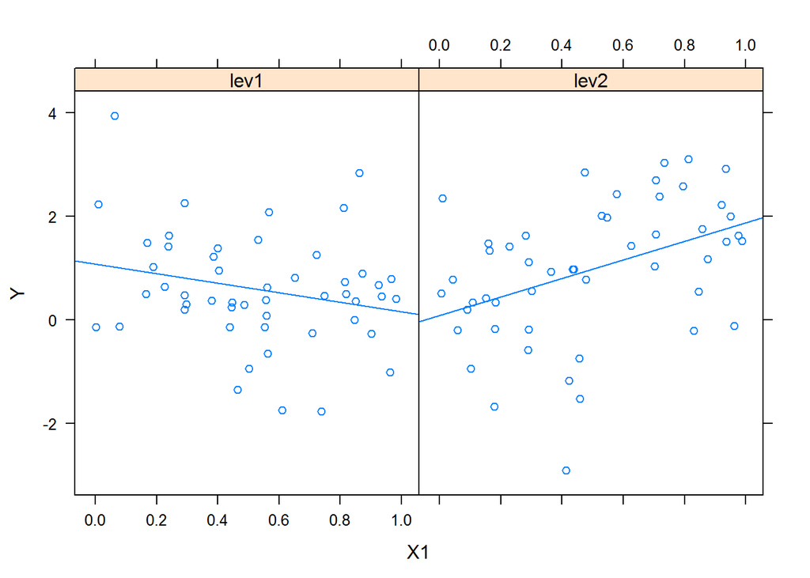

```r
library(lattice)
xyplot(Y~ X1|X2,type=c("p","r"),data=data)
```

```r
library(nlme)
lmList(Y~ X1|X2,data=data)
```

```
## Call:
##   Model: Y ~ X1 | X2
##    Data: data
##
## Coefficients:
##      (Intercept)         X1
## lev1  1.07348571 -0.9170608
## lev2  0.08303964  1.7852389
##
## Degrees of freedom: 100 total; 96 residual
## Residual standard error: 1.147574
```

```r
#As we see value of variable Y differ for different levels of categorical variable.

model<-lm(Y~X1*X2, data=data)
summary(aov(model))[[1]][3,5]
```

```
## [1] 0.000887596
```

From results of ANCOVA we conclude that interactions of variables has significant contribution to variable Y.

## Simulation procedure for first scenario

In first scenario random noise in variable Y is from normal distribution.

I create function “pvals” which extracts p-values for certain sample size and function “power” calculating power of the test for selected number of replications and significance level for first scenario.

```r
pvals <- function(n){
  X_1<-runif(n)
  X_2<-rep(c("lev1","lev2"), length.out=n)
  eps<-rnorm(n)
  Y<- eps+ ifelse(X_2=="lev1" & X_1<0.3, 1.5, 0.5) + ifelse(X_2=="lev2"& X_1>0.5,1,0)
  data<-data.frame(Y,cont=X_1,categ=factor(X_2))
  model<-lm(Y~cont*categ, data=data)
  pval_inter<-summary(aov(model))[[1]][3,5]
  pval_norm<-shapiro.test(rstandard(model))$p.value
  return(c(pval_inter,pval_norm))
}

power <- function (n, alpha) {
  p_vals <- replicate(H, pvals(n))
  power_inter<- mean(p_vals[1,] < alpha)
  power_norm<-mean(p_vals[2,] < alpha)
  return(c(power_inter,power_norm))
}
```

## Simulation procedure for second scenario

In second scenario random noise in variable Y is from Cauchy distribution.

```r
pvals2 <- function(n){
  X_1<-runif(n)
  X_2<-rep(c("lev1","lev2"), length.out=n)
  eps<-rcauchy(n,0,1)
  Y<- eps+ ifelse(X_2=="lev1" & X_1<0.3, 1.5, 0.5) + ifelse(X_2=="lev2"& X_1>0.5,1,0)
  data<-data.frame(Y,cont=X_1,categ=factor(X_2))
  model<-lm(Y~cont*categ, data=data)
  pval_inter<-summary(aov(model))[[1]][3,5]
  pval_norm<-shapiro.test(rstandard(model))$p.value
  return(c(pval_inter,pval_norm))
}

power2 <- function (n, alpha) {
  p_vals <- replicate(H, pvals2(n))
  power_inter<- mean(p_vals[1,] < alpha)
  power_norm<-mean(p_vals[2,] < alpha)
  return(c(power_inter,power_norm))
}
```

## Simulation procedure for third scenario

```r
pvals3 <- function(n){
  X_1<-runif(n)
  X_2<-rep(c("lev1","lev2"), length.out=n)
  eps<-rexp(n, 1)
  Y<- eps+ ifelse(X_2=="lev1" & X_1<0.3, 1.5, 0.5) + ifelse(X_2=="lev2"& X_1>0.5,1,0)
  data<-data.frame(Y,cont=X_1,categ=factor(X_2))
  model<-lm(Y~cont*categ, data=data)
  pval_inter<-summary(aov(model))[[1]][3,5]
  pval_norm<-shapiro.test(rstandard(model))$p.value
  return(c(pval_inter,pval_norm))
}

power3 <- function (n, alpha) {
  p_vals <- replicate(H, pvals2(n))
  power_inter<- mean(p_vals[1,] < alpha)
  power_norm<-mean(p_vals[2,] < alpha)
  return(c(power_inter,power_norm))
}
```

## Results of simulations

```r
H<-200
alpha<-0.05 # significance level

size <- seq(10, 140, by=1) #sample size
power1 <- sapply(size, function (x) power(x, alpha))
power2 <- sapply(size, function (x) power2(x, alpha))
power3 <- sapply(size, function (x) power3(x, alpha))
```

## Power of ANCOVA

I prepare plot that will compare power as a function of sample size for each scenario and additional plot comparing results for first and second scenario.

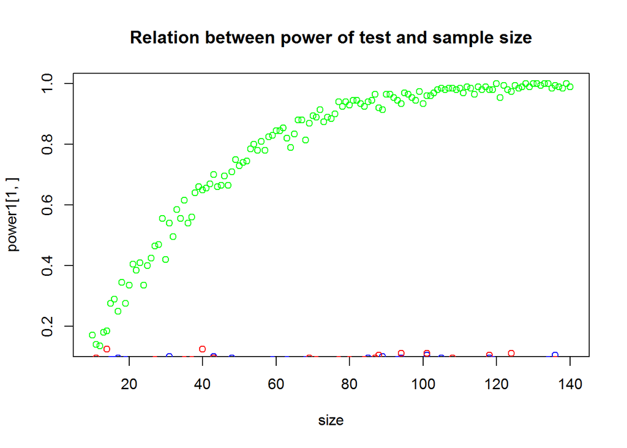

```r
plot(size,power1[1,], main = "Relation between power of test and sample size", col='green')
points(size,power2[1,], col='blue')
points(size,power3[1,],  col='red')
```

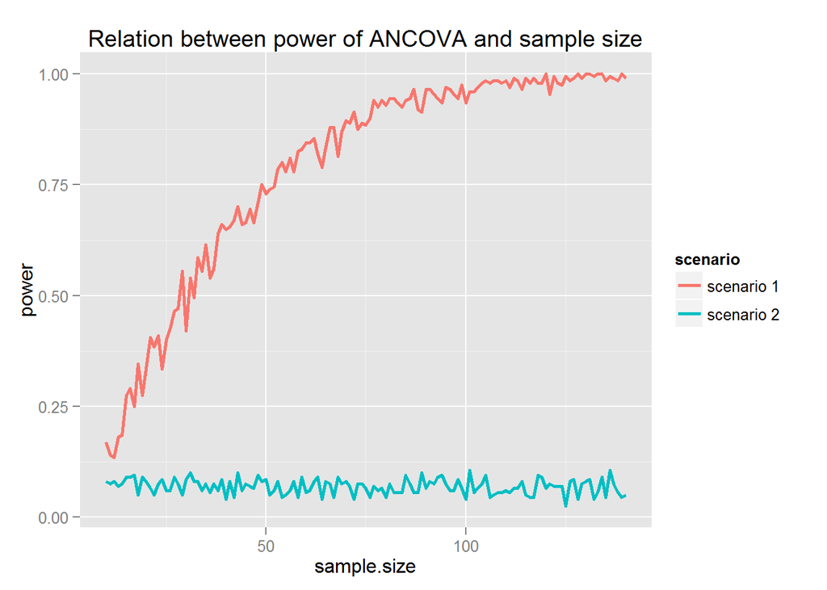

```r
frame_inter<-data.frame(sample.size=rep(size,times=2), power=c(power1[1,], power2[1,]),
                        scenario=rep(c("scenario 1", "scenario 2"), each=length(size)))

ggplot(frame_inter, aes(x=sample.size, y=power, group=scenario, colour=scenario)) + geom_line(size=1) +
  ggtitle("Relation between power of ANCOVA and sample size")
```

We can observe that power for second scenario is lower than for first scenario.

## Normality of residuals

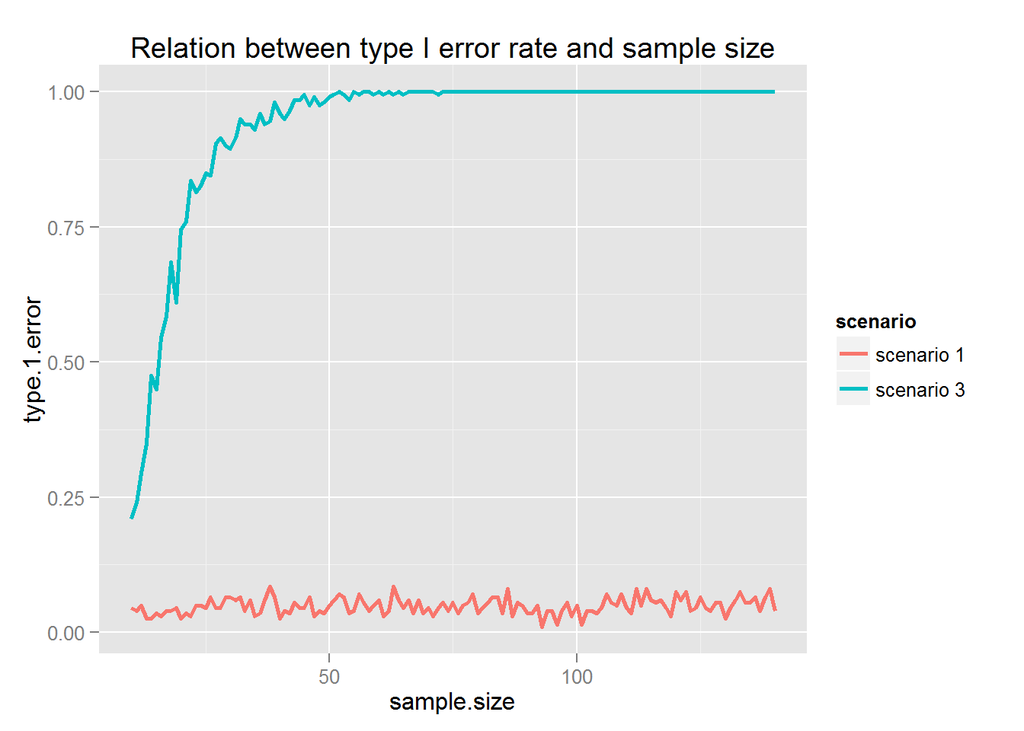

```r
frame_norm<- data.frame(sample.size=rep(size,times=2), type.1.error=c(power1[2,], power3[2,]),
                        scenario=rep(c("scenario 1", "scenario 3"), each=length(size)))

ggplot(frame_norm, aes(x=sample.size, y=type.1.error, group=scenario, colour=scenario)) + geom_line(size=1) +
  ggtitle("Relation between type I error rate and sample size")
```

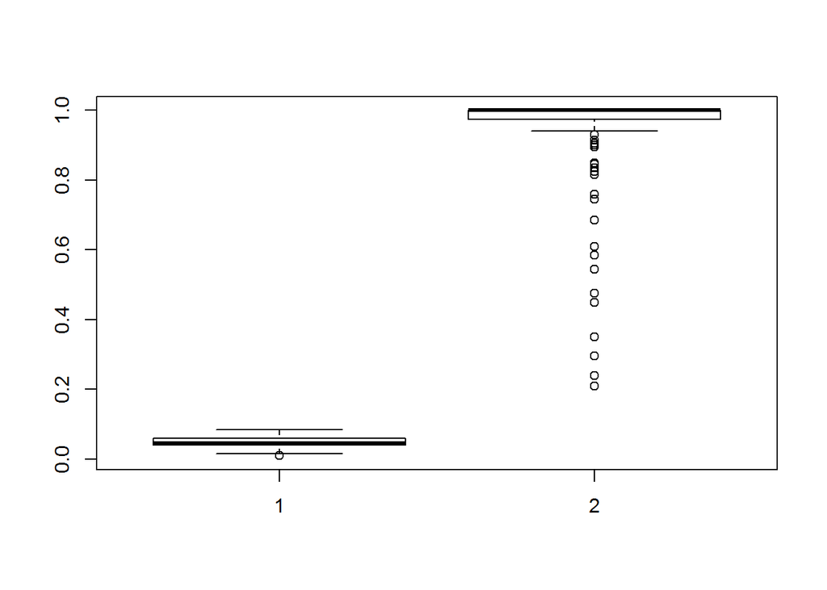

```r
# Boxplot for average type I error for first and third scenario
boxplot(power1[2,], power3[2,])
```

It is clear that I type error rate is different for first scenario and third scenario.